# EDA

Autores:

- Martín Hijar Jiménez
- Eduardo Salgado Díaz del Río

31 de octubre de 2022

Asignatura: Machine Learning - Máster en Data Science

### Objetivo de la práctica

El objetivo de la práctica es realizar un análisis exploratorio del dataset ticdata

### Dataset

Es un conjunto de datos para entrenar y validar modelos de predicción mediante Machine learning, aunque en la primera fase del proyecto, realizaremos un análisis EDA.

Los datos sociodemográficos estan delimitados por el rango 1-43, y los datos se derivan de los códigos postales, todos los clientes que tienen un mismo codigo postal tienen los mismos atributos. El dataset consta de 86 variables, con diferentes tipos de variables siendo algunas numericas y otras categoricas. La variable Caravans es la variable objetivo. Dentro de las distintas variables tienen diferentes subconjuntos definidos de L0 a L4.

En primer lugar, creamos un diccionario para realizar un análisis previo de las distintas variable, para la utilización del dataset, creando diferentes subgrupos dentro del conjunto de analisis como número, nombre , descripción , tipo y categoria.

### Librerias

En primer lugar, cargaremos las librerias que se utilizaran para el estudio.

```python
import pandas as pd
import numpy as np
import seaborn as sns
from matplotlib import pyplot as plt
import plotly.express as px
import requests
import pandas_profiling
from pandas_profiling.utils.cache import cache_file
from sklearn.impute import KNNImputer
import scipy.stats as ss
import warnings
warnings.filterwarnings('ignore')
```

Importamos las funciones auxiliares que vamos a utilizar proximamente.

```python
from support_functions import *
```

### Leer Dataset

- Para realizar el EDA utilizamos sólo los datos del archivo ticdata2000. Es un conjunto de datos para entrenar y validar modelos de predicción y construir una descripción (5822 registros de clientes). Cada registro consta de 86 atributos, que contienen datos sociodemográficos (atributos 1-43) y propiedad de productos (atributos 44-86).Los datos sociodemográficos se derivan de los códigos postales. Todos los clientes que viven en zonas con el mismo código postal tienen los mismos atributos sociodemográficos. El atributo 86, "CARAVAN:Número de pólizas de casas móviles", es la variable objetivo.
- En el caso de querer generar un modelo predictivo habría que añadir el resto de los datos (ticeval2000 y tictgts2000) y aplicar las mismas operaciones que realizamos a continuación sobre los datos de ticdata, para poder leer correctamente los datos.

```python
# Leemos los sólo los datos de train
df = pd.read_csv('../data/raw/ticdata2000.txt', sep='\t', header=None)
# df_ticeval = pd.read_csv('../data/raw/ticeval2000.txt', sep='\t', header=None)
# df_tictgts = pd.read_csv('../data/raw/tictgts2000.txt', sep='\t', header=None)
```

##### Cambiamos el nombre a las diferentes columnas del dataset, para poder utilizar el dataset de una forma mas sencilla.

```python
list_columns = ["MOSTYPE", "MAANTHUI", "MGEMOMV",
                        "MGEMLEEF", "MOSHOOFD", "MGODRK",
                        "MGODPR", "MGODOV", "MGODGE",
                        "MRELGE", "MRELSA", "MRELOV", "MFALLEEN",
                        "MFGEKIND", "MFWEKIND", "MOPLHOOG", "MOPLMIDD",
                        "MOPLLAAG", "MBERHOOG", "MBERZELF",
                        "MBERBOER", "MBERMIDD", "MBERARBG", "MBERARBO",
                        "MSKA","MSKB1", "MSKB2", "MSKC",
                        "MSKD", "MHHUUR", "MHKOOP", "MAUT1", "MAUT2",
                        "MAUT0", "MZFONDS", "MZPART", "MINKM30",
                        "MINK3045", "MINK4575", "MINK7512", "MINK123M",
                        "MINKGEM", "MKOOPKLA", "PWAPART", "PWABEDR", "PWALAND",
                        "PPERSAUT", "PBESAUT", "PMOTSCO", "PVRAAUT",
                        "PAANHANG", "PTRACTOR", "PWERKT", "PBROM",
                        "PLEVEN", "PPERSONG", "PGEZONG", "PWAOREG",
                        "PBRAND", "PZEILPL", "PPLEZIER", "PFIETS","PINBOED", "PBYSTAND","AWAPART","AWABEDR",
                        "AWALAND","APERSAUT","ABESAUT","AMOTSCO","AVRAAUT","AAANHANG","ATRACTOR",
                         "AWERKT","ABROM","ALEVEN","APERSONG","AGEZONG","AWAOREG","ABRAND","AZEILPL","APLEZIER",
                         "AFIETS", "AINBOED", "ABYSTAND", "CARAVAN"]

df.columns = list_columns
```

##### Visualizar Data Frame

```python
df.head()
```

|  | MOSTYPE | MAANTHUI | MGEMOMV | MGEMLEEF | MOSHOOFD | MGODRK | MGODPR | MGODOV | MGODGE | MRELGE | ... | APERSONG | AGEZONG | AWAOREG | ABRAND | AZEILPL | APLEZIER | AFIETS | AINBOED | ABYSTAND | CARAVAN |
| --- | --- | --- | --- | --- | --- | --- | --- | --- | --- | --- | --- | --- | --- | --- | --- | --- | --- | --- | --- | --- | --- |
| 0 | 33 | 1 | 3 | 2 | 8 | 0 | 5 | 1 | 3 | 7 | ... | 0 | 0 | 0 | 1 | 0 | 0 | 0 | 0 | 0 | 0 |
| 1 | 37 | 1 | 2 | 2 | 8 | 1 | 4 | 1 | 4 | 6 | ... | 0 | 0 | 0 | 1 | 0 | 0 | 0 | 0 | 0 | 0 |
| 2 | 37 | 1 | 2 | 2 | 8 | 0 | 4 | 2 | 4 | 3 | ... | 0 | 0 | 0 | 1 | 0 | 0 | 0 | 0 | 0 | 0 |
| 3 | 9 | 1 | 3 | 3 | 3 | 2 | 3 | 2 | 4 | 5 | ... | 0 | 0 | 0 | 1 | 0 | 0 | 0 | 0 | 0 | 0 |
| 4 | 40 | 1 | 4 | 2 | 10 | 1 | 4 | 1 | 4 | 7 | ... | 0 | 0 | 0 | 1 | 0 | 0 | 0 | 0 | 0 | 0 |

5 rows × 86 columns

#### Tipos de datos

Mediante la función dtypes, encontramos el tipo de cada variable, en el caso de este dataset todas las varibles son de tipo int64.

```python
df.dtypes.unique()
```

```
array([dtype('int64')], dtype=object)
```

## Proporción de 0 y 1 de la variable objetivo respecto a los casos que contratan caravana

La variable objetivo es la columna Caravan, que representa el número de policas.

```python
# Cogemos la variable objetivo q es la de los interesados en contratar un seguro de caravana
# Clientes potencciales que buscan un seguro de caravana
plot_df_caravans = df['CARAVAN']\
        .value_counts(normalize=True)\
        .mul(100).rename('percent').reset_index()

plot_df_caravans_conteo = df['CARAVAN'].value_counts().reset_index()
plot_df_caravans_pc = pd.merge(plot_df_caravans, plot_df_caravans_conteo, on=['index'], how='inner')
plot_df_caravans_pc
```

|  | index | percent | CARAVAN |
| --- | --- | --- | --- |
| 0 | 0 | 94.022673 | 5474 |
| 1 | 1 | 5.977327 | 348 |

#### Representación gráfica de la distribución de la variable objetivo

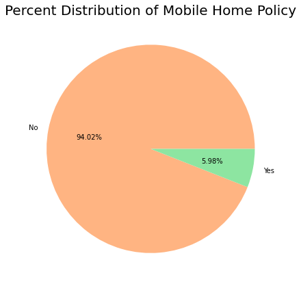

```python
colors = sns.color_palette('pastel')[1:3]

fig, ax = plt.subplots(figsize=(7,7))
plt.pie(plot_df_caravans['percent'], labels = ['No', 'Yes'], colors = colors, autopct='%.2f%%')
plt.title('Percent Distribution of Mobile Home Policy', fontsize = 20)
plt.show()
```

# Análisis de duplicados

Observamos cuantas partes del dataset están duplicados, un total de 602 datos estan duplicadas, hemos decidido mantener los datos duplicados.

```python
#observamos los duplicados
print(df.shape, df.drop_duplicates().shape)
```

```
(5822, 86) (5220, 86)
```

### Missing values

Búsquedad de valores nulos en las variables, el dataset esta completo, por lo tanto no tienen valores nulos o missing.

```python
pd.isnull(df[[x for x in df.columns[pd.isna(df).any()].tolist()]]).sum()
```

```
Series([], dtype: float64)
```

## Análisis de las variables numéricas

Transformamos las variables categóricas que nos interesan en numéricas.

Modificamos la columna MGEMLEEF que representa la edad,que es de tipo catégorica a la misma variable con el mismo nombre que es númerica, aplicamos un nuevo valor a cada fila que es la media del rango que vamos a utilizar.

Por ejemplo: si MGEMLEEF es 1 (representa el rango 20-30), lo sustituimos por 25 para poder tratarla como una variable numérica. Y así sucesivamente para cada una de las 6 filas.

```python
# La columna 'MGEMLEEF' es una variable categórica que representa la edad, la convertimos a numérica poniendo el valor medio del rango que representa.
# Por ejemplo: si MGEMLEEF es 1 (representa el rango 20-30), lo sustituimos por 25 para poder tratarla como una variable numérica.

df.loc[df['MGEMLEEF'] == 1, 'MGEMLEEF']=25
df.loc[df['MGEMLEEF'] == 2, 'MGEMLEEF']=35
df.loc[df['MGEMLEEF'] == 3, 'MGEMLEEF']=45
df.loc[df['MGEMLEEF'] == 4, 'MGEMLEEF']=55
df.loc[df['MGEMLEEF'] == 5, 'MGEMLEEF']=65
df.loc[df['MGEMLEEF'] == 6, 'MGEMLEEF']=75
[df['MGEMLEEF']]
```

```
[0       35
 1       35
 2       35
 3       45
 4       35
         ..
 5817    35
 5818    55
 5819    55
 5820    35
 5821    45
 Name: MGEMLEEF, Length: 5822, dtype: int64]
```

### Creamos un nuevo dataframe unicamente con las variables númericas del dataset

```python
df_num = df.iloc[:,[1,2,3,*range(65,85)]]
df_num.head()
```

|  | MAANTHUI | MGEMOMV | MGEMLEEF | AWABEDR | AWALAND | APERSAUT | ABESAUT | AMOTSCO | AVRAAUT | AAANHANG | ... | ALEVEN | APERSONG | AGEZONG | AWAOREG | ABRAND | AZEILPL | APLEZIER | AFIETS | AINBOED | ABYSTAND |
| --- | --- | --- | --- | --- | --- | --- | --- | --- | --- | --- | --- | --- | --- | --- | --- | --- | --- | --- | --- | --- | --- |
| 0 | 1 | 3 | 35 | 0 | 0 | 1 | 0 | 0 | 0 | 0 | ... | 0 | 0 | 0 | 0 | 1 | 0 | 0 | 0 | 0 | 0 |
| 1 | 1 | 2 | 35 | 0 | 0 | 0 | 0 | 0 | 0 | 0 | ... | 0 | 0 | 0 | 0 | 1 | 0 | 0 | 0 | 0 | 0 |
| 2 | 1 | 2 | 35 | 0 | 0 | 1 | 0 | 0 | 0 | 0 | ... | 0 | 0 | 0 | 0 | 1 | 0 | 0 | 0 | 0 | 0 |
| 3 | 1 | 3 | 45 | 0 | 0 | 1 | 0 | 0 | 0 | 0 | ... | 0 | 0 | 0 | 0 | 1 | 0 | 0 | 0 | 0 | 0 |
| 4 | 1 | 4 | 35 | 0 | 0 | 0 | 0 | 0 | 0 | 0 | ... | 0 | 0 | 0 | 0 | 1 | 0 | 0 | 0 | 0 | 0 |

5 rows × 23 columns

### Correlación entre las variables numéricas

Se procede a construir la matriz de correlaciones de forma numérica y luego gráfica, a fin de ver las posibles correlaciones entre las variables disponibles.

```python
df_num.corr()
```

|  | MAANTHUI | MGEMOMV | MGEMLEEF | AWABEDR | AWALAND | APERSAUT | ABESAUT | AMOTSCO | AVRAAUT | AAANHANG | ... | ALEVEN | APERSONG | AGEZONG | AWAOREG | ABRAND | AZEILPL | APLEZIER | AFIETS | AINBOED | ABYSTAND |
| --- | --- | --- | --- | --- | --- | --- | --- | --- | --- | --- | --- | --- | --- | --- | --- | --- | --- | --- | --- | --- | --- |
| MAANTHUI | 1.000000 | 0.010102 | 0.056975 | 0.004693 | -0.027627 | -0.029427 | -0.018716 | -0.019295 | -0.009690 | -0.010349 | ... | 0.020926 | 0.003321 | 0.009444 | -0.016333 | 0.000655 | -0.006189 | 0.000666 | -0.020993 | 0.018304 | -0.004166 |
| MGEMOMV | 0.010102 | 1.000000 | -0.328257 | 0.035062 | 0.036039 | 0.020598 | -0.009047 | 0.013076 | 0.000608 | 0.014608 | ... | 0.017428 | -0.000128 | 0.016760 | 0.018749 | -0.009269 | 0.009234 | 0.000644 | 0.030330 | 0.025907 | 0.028384 |
| MGEMLEEF | 0.056975 | -0.328257 | 1.000000 | -0.008249 | 0.007497 | -0.015807 | 0.021958 | -0.015571 | -0.013046 | 0.006102 | ... | -0.025187 | 0.021070 | -0.001747 | 0.000644 | 0.024417 | 0.000244 | -0.001791 | 0.020612 | -0.020042 | -0.014540 |
| AWABEDR | 0.004693 | 0.035062 | -0.008249 | 1.000000 | 0.029091 | -0.019795 | 0.178323 | -0.014154 | 0.098025 | 0.101031 | ... | 0.008181 | -0.008058 | -0.008927 | 0.191960 | 0.052349 | -0.002501 | -0.008112 | -0.016589 | 0.018695 | -0.002413 |
| AWALAND | -0.027627 | 0.036039 | 0.007497 | 0.029091 | 1.000000 | 0.091038 | 0.016209 | -0.004890 | -0.005157 | 0.081662 | ... | -0.000617 | 0.039221 | 0.018267 | 0.053787 | 0.134636 | -0.003294 | 0.004126 | -0.016120 | 0.000693 | 0.002914 |
| APERSAUT | -0.029427 | 0.020598 | -0.015807 | -0.019795 | 0.091038 | 1.000000 | 0.038695 | 0.065304 | 0.030259 | 0.045082 | ... | 0.093493 | 0.006137 | 0.044575 | 0.003014 | 0.025842 | -0.008593 | 0.046364 | -0.029624 | 0.031840 | 0.104963 |
| ABESAUT | -0.018716 | -0.009047 | 0.021958 | 0.178323 | 0.016209 | 0.038695 | 1.000000 | 0.014405 | 0.165436 | 0.181096 | ... | 0.029146 | -0.005898 | -0.006534 | 0.029318 | 0.000529 | -0.001830 | -0.005937 | -0.005878 | -0.007041 | 0.012449 |
| AMOTSCO | -0.019295 | 0.013076 | -0.015571 | -0.014154 | -0.004890 | 0.065304 | 0.014405 | 1.000000 | -0.006374 | 0.005985 | ... | 0.039128 | 0.017807 | -0.005217 | -0.001051 | -0.019020 | -0.004071 | -0.004015 | -0.012782 | 0.009220 | 0.022464 |
| AVRAAUT | -0.009690 | 0.000608 | -0.013046 | 0.098025 | -0.005157 | 0.030259 | 0.165436 | -0.006374 | 1.000000 | 0.083427 | ... | -0.007213 | -0.002601 | -0.002881 | 0.033201 | -0.006865 | -0.000807 | -0.002618 | 0.020569 | -0.003105 | -0.004224 |
| AAANHANG | -0.010349 | 0.014608 | 0.006102 | 0.101031 | 0.081662 | 0.045082 | 0.181096 | 0.005985 | 0.083427 | 1.000000 | ... | 0.005093 | 0.011472 | 0.008879 | 0.046965 | 0.032525 | 0.057917 | 0.026121 | -0.008543 | 0.036587 | -0.011846 |
| ATRACTOR | -0.027570 | 0.058681 | -0.005504 | 0.069714 | 0.547175 | 0.084731 | 0.043620 | -0.006376 | 0.074541 | 0.059810 | ... | -0.009477 | 0.048592 | 0.024107 | 0.074589 | 0.112055 | -0.003175 | -0.001558 | -0.010917 | -0.004327 | 0.019063 |
| AWERKT | -0.006756 | 0.027257 | 0.005630 | 0.128584 | 0.099864 | 0.038339 | 0.379082 | -0.008928 | 0.042271 | 0.193004 | ... | -0.002776 | 0.072382 | -0.004036 | 0.050631 | 0.020863 | -0.001131 | -0.003667 | -0.007500 | -0.004349 | -0.005916 |
| ABROM | -0.013336 | 0.018615 | 0.000471 | -0.029258 | -0.006616 | -0.162322 | -0.021414 | -0.039142 | -0.009444 | -0.011030 | ... | -0.041891 | -0.019437 | -0.005440 | -0.015918 | -0.183002 | -0.006032 | -0.019566 | -0.027728 | -0.023204 | -0.015364 |
| ALEVEN | 0.020926 | 0.017428 | -0.025187 | 0.008181 | -0.000617 | 0.093493 | 0.029146 | 0.039128 | -0.007213 | 0.005093 | ... | 1.000000 | 0.016411 | 0.119149 | -0.006280 | 0.092078 | -0.004607 | -0.003797 | 0.003942 | 0.032572 | 0.017600 |
| APERSONG | 0.003321 | -0.000128 | 0.021070 | -0.008058 | 0.039221 | 0.006137 | -0.005898 | 0.017807 | -0.002601 | 0.011472 | ... | 0.016411 | 1.000000 | -0.005930 | -0.004384 | 0.013974 | -0.001661 | 0.023526 | -0.011020 | -0.006391 | -0.008693 |
| AGEZONG | 0.009444 | 0.016760 | -0.001747 | -0.008927 | 0.018267 | 0.044575 | -0.006534 | -0.005217 | -0.002881 | 0.008879 | ... | 0.119149 | -0.005930 | 1.000000 | -0.004857 | 0.039232 | -0.001840 | -0.005970 | 0.038345 | 0.016501 | 0.114810 |
| AWAOREG | -0.016333 | 0.018749 | 0.000644 | 0.191960 | 0.053787 | 0.003014 | 0.029318 | -0.001051 | 0.033201 | 0.046965 | ... | -0.006280 | -0.004384 | -0.004857 | 1.000000 | 0.033991 | -0.001361 | -0.004413 | -0.009025 | -0.005234 | -0.007119 |
| ABRAND | 0.000655 | -0.009269 | 0.024417 | 0.052349 | 0.134636 | 0.025842 | 0.000529 | -0.019020 | -0.006865 | 0.032525 | ... | 0.092078 | 0.013974 | 0.039232 | 0.033991 | 1.000000 | 0.003902 | 0.000177 | -0.031095 | 0.026274 | 0.034854 |
| AZEILPL | -0.006189 | 0.009234 | 0.000244 | -0.002501 | -0.003294 | -0.008593 | -0.001830 | -0.004071 | -0.000807 | 0.057917 | ... | -0.004607 | -0.001661 | -0.001840 | -0.001361 | 0.003902 | 1.000000 | 0.091052 | -0.003420 | 0.081689 | -0.002698 |
| APLEZIER | 0.000666 | 0.000644 | -0.001791 | -0.008112 | 0.004126 | 0.046364 | -0.005937 | -0.004015 | -0.002618 | 0.026121 | ... | -0.003797 | 0.023526 | -0.005970 | -0.004413 | 0.000177 | 0.091052 | 1.000000 | -0.011093 | 0.040094 | 0.026325 |
| AFIETS | -0.020993 | 0.030330 | 0.020612 | -0.016589 | -0.016120 | -0.029624 | -0.005878 | -0.012782 | 0.020569 | -0.008543 | ... | 0.003942 | -0.011020 | 0.038345 | -0.009025 | -0.031095 | -0.003420 | -0.011093 | 1.000000 | 0.004845 | 0.009246 |
| AINBOED | 0.018304 | 0.025907 | -0.020042 | 0.018695 | 0.000693 | 0.031840 | -0.007041 | 0.009220 | -0.003105 | 0.036587 | ... | 0.032572 | -0.006391 | 0.016501 | -0.005234 | 0.026274 | 0.081689 | 0.040094 | 0.004845 | 1.000000 | 0.021273 |
| ABYSTAND | -0.004166 | 0.028384 | -0.014540 | -0.002413 | 0.002914 | 0.104963 | 0.012449 | 0.022464 | -0.004224 | -0.011846 | ... | 0.017600 | -0.008693 | 0.114810 | -0.007119 | 0.034854 | -0.002698 | 0.026325 | 0.009246 | 0.021273 | 1.000000 |

23 rows × 23 columns

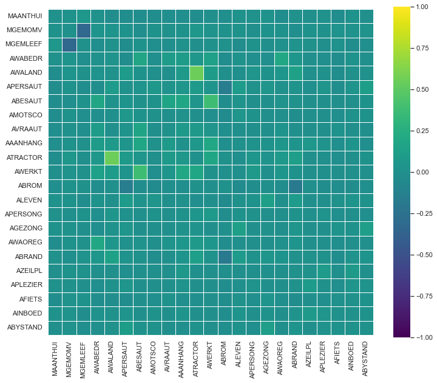

```
0
```

```python
get_corr_matrix(dataset = df_num,
                metodo='pearson', size_figure=[12,10])
```

Vemos como hay diferentes variables con una fuerte correlación directa como: 'AWALAND' y 'ATRACTOR'.

- AWALAND es el númoer de seguros a terceros en la agricultura.
- ATRACTOR representa el número de polizas para tractores Number of tractor policies.

- MGEMOMV es el tamaño medio del hogar
- MGEMLEEF representa la edad media

## Análisis de las variables categóricas

Data Frame con sólo las variables categóricas

```python
df_cat = df.iloc[:,[0,*range(4,65)]]
df_cat.head()
```

|  | MOSTYPE | MOSHOOFD | MGODRK | MGODPR | MGODOV | MGODGE | MRELGE | MRELSA | MRELOV | MFALLEEN | ... | PPERSONG | PGEZONG | PWAOREG | PBRAND | PZEILPL | PPLEZIER | PFIETS | PINBOED | PBYSTAND | AWAPART |
| --- | --- | --- | --- | --- | --- | --- | --- | --- | --- | --- | --- | --- | --- | --- | --- | --- | --- | --- | --- | --- | --- |
| 0 | 33 | 8 | 0 | 5 | 1 | 3 | 7 | 0 | 2 | 1 | ... | 0 | 0 | 0 | 5 | 0 | 0 | 0 | 0 | 0 | 0 |
| 1 | 37 | 8 | 1 | 4 | 1 | 4 | 6 | 2 | 2 | 0 | ... | 0 | 0 | 0 | 2 | 0 | 0 | 0 | 0 | 0 | 2 |
| 2 | 37 | 8 | 0 | 4 | 2 | 4 | 3 | 2 | 4 | 4 | ... | 0 | 0 | 0 | 2 | 0 | 0 | 0 | 0 | 0 | 1 |
| 3 | 9 | 3 | 2 | 3 | 2 | 4 | 5 | 2 | 2 | 2 | ... | 0 | 0 | 0 | 2 | 0 | 0 | 0 | 0 | 0 | 0 |
| 4 | 40 | 10 | 1 | 4 | 1 | 4 | 7 | 1 | 2 | 2 | ... | 0 | 0 | 0 | 6 | 0 | 0 | 0 | 0 | 0 | 0 |

5 rows × 62 columns

Cramer's V Matriz de Correlación

La función recibe dos variables y devuelve su correlación. Hemos decidido comparar todas las variables entre sí.

```python
rows= []

for var1 in df_cat:
  col = []
  for var2 in df_cat :
    cramers =cramers_v(df_cat[var1], df_cat[var2]) # Cramer's V test
    col.append(round(cramers,2)) # Keeping of the rounded value of the Cramer's V
  rows.append(col)

cramers_results = np.array(rows)
df_vcramer = pd.DataFrame(cramers_results, columns = df_cat.columns, index =df_cat.columns)



df_vcramer
```

|  | MOSTYPE | MOSHOOFD | MGODRK | MGODPR | MGODOV | MGODGE | MRELGE | MRELSA | MRELOV | MFALLEEN | ... | PPERSONG | PGEZONG | PWAOREG | PBRAND | PZEILPL | PPLEZIER | PFIETS | PINBOED | PBYSTAND | AWAPART |
| --- | --- | --- | --- | --- | --- | --- | --- | --- | --- | --- | --- | --- | --- | --- | --- | --- | --- | --- | --- | --- | --- |
| MOSTYPE | 1.00 | 1.00 | 0.16 | 0.19 | 0.21 | 0.19 | 0.28 | 0.20 | 0.29 | 0.28 | ... | 0.00 | 0.02 | 0.05 | 0.17 | 0.00 | 0.02 | 0.05 | 0.03 | 0.04 | 0.09 |
| MOSHOOFD | 1.00 | 1.00 | 0.09 | 0.11 | 0.12 | 0.10 | 0.21 | 0.14 | 0.20 | 0.20 | ... | 0.02 | 0.03 | 0.00 | 0.16 | 0.03 | 0.00 | 0.03 | 0.02 | 0.05 | 0.06 |
| MGODRK | 0.16 | 0.09 | 1.00 | 0.22 | 0.17 | 0.12 | 0.10 | 0.17 | 0.10 | 0.07 | ... | 0.00 | 0.00 | 0.00 | 0.01 | 0.00 | 0.00 | 0.02 | 0.00 | 0.00 | 0.03 |
| MGODPR | 0.19 | 0.11 | 0.22 | 1.00 | 0.25 | 0.43 | 0.14 | 0.17 | 0.13 | 0.10 | ... | 0.01 | 0.00 | 0.00 | 0.06 | 0.00 | 0.02 | 0.00 | 0.00 | 0.02 | 0.01 |
| MGODOV | 0.21 | 0.12 | 0.17 | 0.25 | 1.00 | 0.16 | 0.18 | 0.24 | 0.20 | 0.14 | ... | 0.00 | 0.00 | 0.00 | 0.03 | 0.00 | 0.00 | 0.02 | 0.00 | 0.00 | 0.00 |
| ... | ... | ... | ... | ... | ... | ... | ... | ... | ... | ... | ... | ... | ... | ... | ... | ... | ... | ... | ... | ... | ... |
| PPLEZIER | 0.02 | 0.00 | 0.00 | 0.02 | 0.00 | 0.00 | 0.02 | 0.00 | 0.00 | 0.00 | ... | 0.03 | 0.00 | 0.00 | 0.00 | 0.29 | 1.00 | 0.00 | 0.05 | 0.00 | 0.00 |
| PFIETS | 0.05 | 0.03 | 0.02 | 0.00 | 0.02 | 0.04 | 0.04 | 0.02 | 0.06 | 0.00 | ... | 0.00 | 0.02 | 0.00 | 0.04 | 0.00 | 0.00 | 1.00 | 0.00 | 0.01 | 0.00 |
| PINBOED | 0.03 | 0.02 | 0.00 | 0.00 | 0.00 | 0.00 | 0.03 | 0.00 | 0.02 | 0.00 | ... | 0.00 | 0.01 | 0.00 | 0.05 | 0.11 | 0.05 | 0.00 | 1.00 | 0.01 | 0.00 |
| PBYSTAND | 0.04 | 0.05 | 0.00 | 0.02 | 0.00 | 0.01 | 0.02 | 0.00 | 0.00 | 0.02 | ... | 0.00 | 0.11 | 0.00 | 0.03 | 0.00 | 0.00 | 0.01 | 0.01 | 1.00 | 0.03 |
| AWAPART | 0.09 | 0.06 | 0.03 | 0.01 | 0.00 | 0.00 | 0.04 | 0.00 | 0.03 | 0.05 | ... | 0.00 | 0.03 | 0.00 | 0.44 | 0.00 | 0.00 | 0.00 | 0.00 | 0.03 | 1.00 |

62 rows × 62 columns

Heatmap de la matriz de correlación previamente obtenida

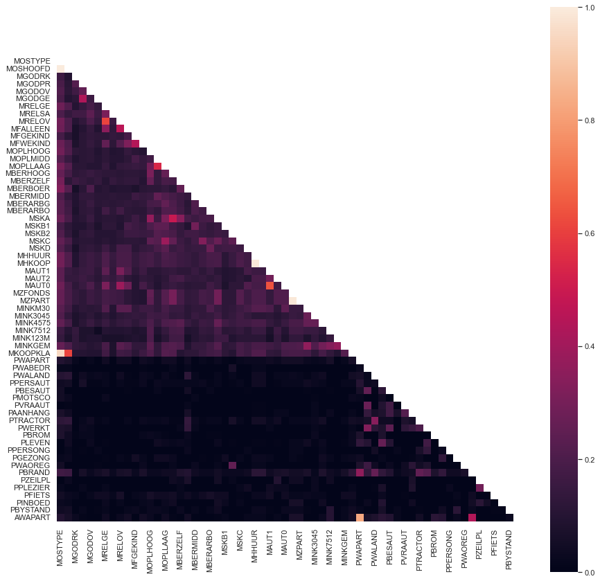

```python
mask = np.zeros_like(df_vcramer, dtype=np.bool)
mask[np.triu_indices_from(mask)] = True

with sns.axes_style("white"):
  fig, axx = plt.subplots(figsize=(15,15))
  ax = sns.heatmap(df_vcramer, mask = mask, vmin=0, vmax=1, square=True, ax=axx)

plt.show()
```

Se observan diferentes variables con correlaciones especialmente altas como 'MKOOPKLA' y 'MOSTYPE'.

- MKOOPKLA, es la clase de poder adquisitivo
- MOSTYPE, es el subtipo de cliente, subclasificado en diferentes tipos como: estudiantes en un apartamento, joven sin educación, familia numerosa religiosa, etc.

Hay más variables que presentan correlaciones muy fuertes, si en un futuro se quiere realizar un model predictivo estudiaremos en detalle que variables utilizar y cuales no.

## Distribución de las variables y ver como afectan a la variable objetivo

### Variables categóricas

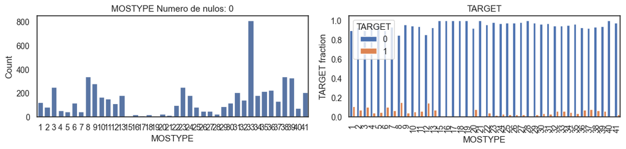

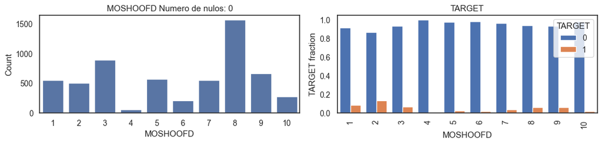

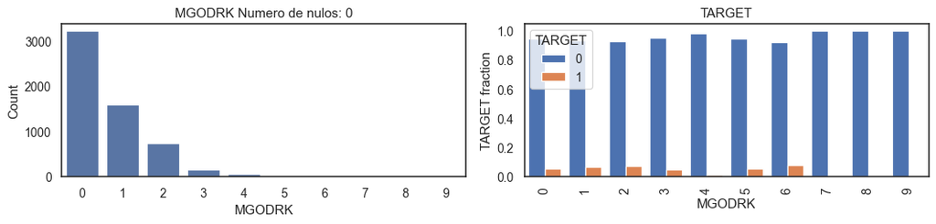

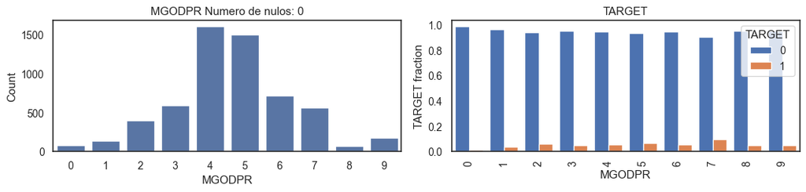

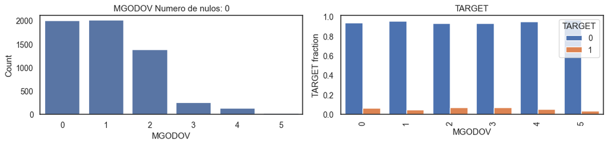

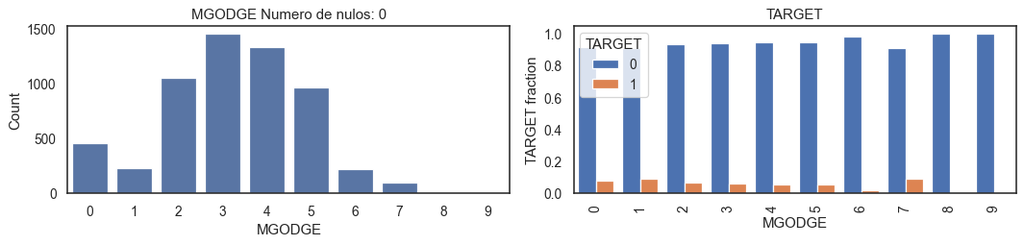

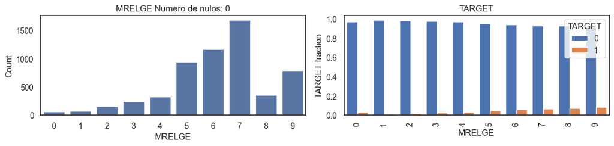

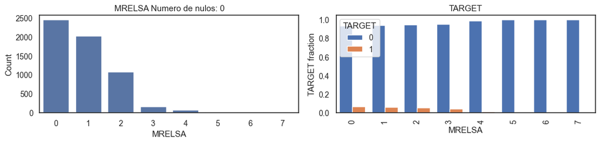

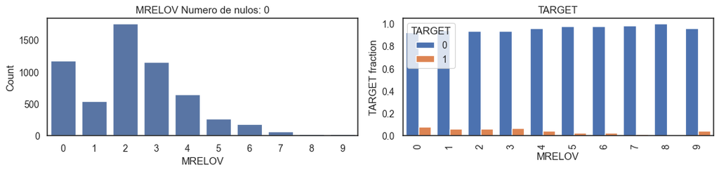

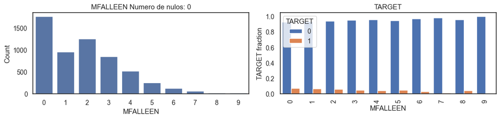

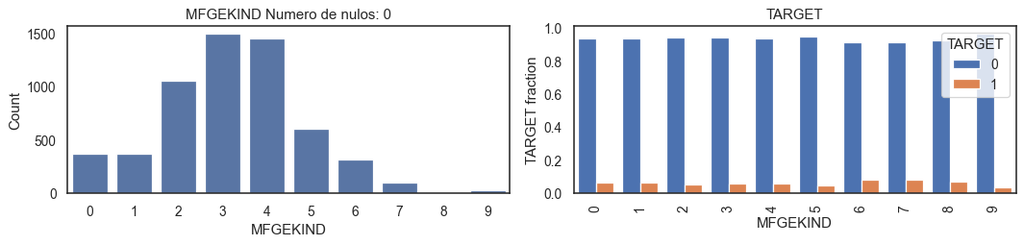

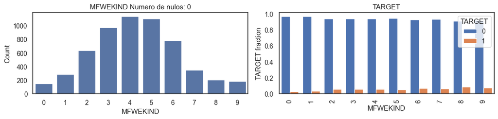

[50 more figures not shown]

```python
df_cat_with_target =  df_cat
df_cat_with_target['TARGET'] = df['CARAVAN']

for i in list(df_cat_with_target.columns):
    if (df_cat_with_target[i].dtype==float) & (i!='TARGET'):
        plot_feature(df_cat_with_target, col_name=i, isContinuous=True, target='TARGET')
    elif  i!='TARGET':
        plot_feature(df_cat_with_target, col_name=i, isContinuous=False, target='TARGET')
```

### Variables Numéricas

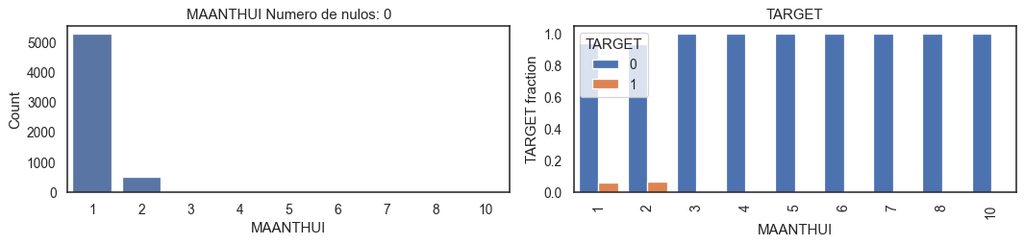

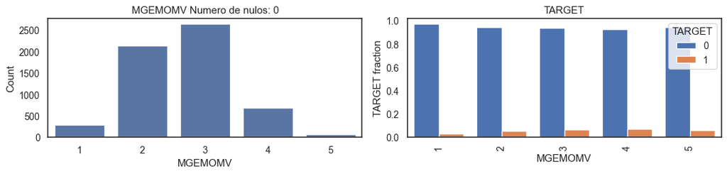

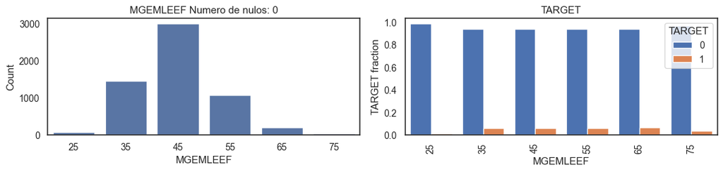

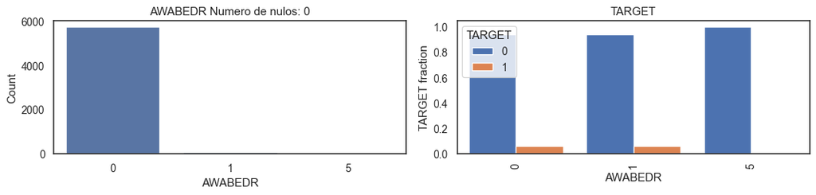

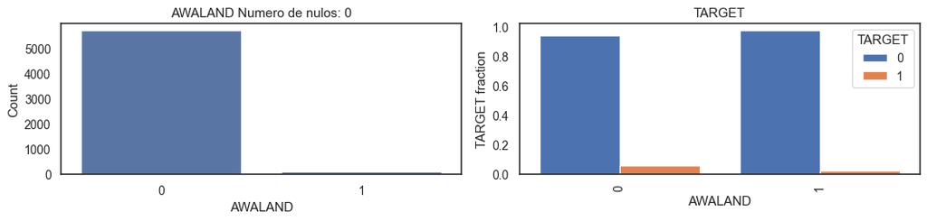

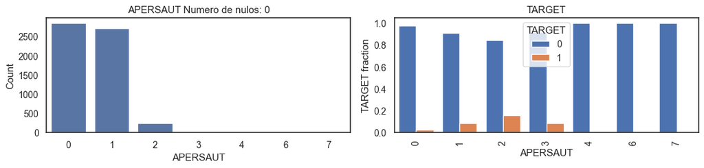

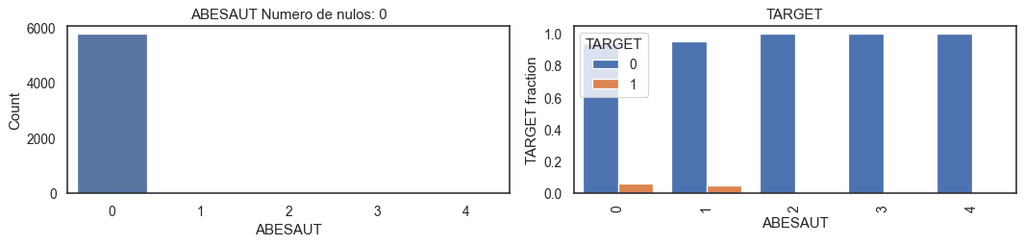

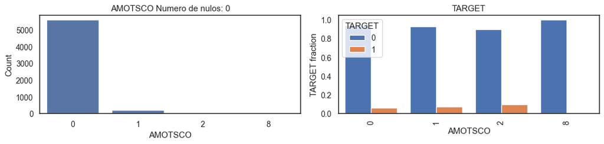

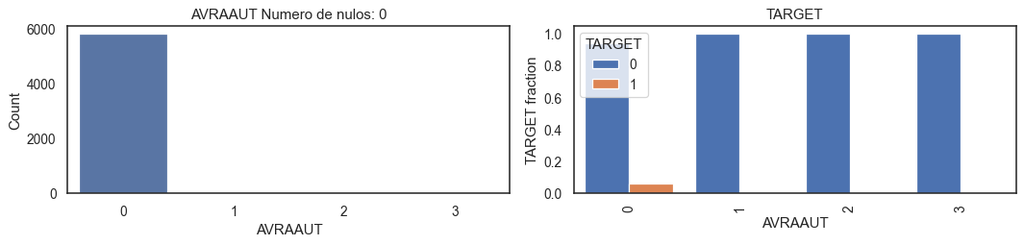

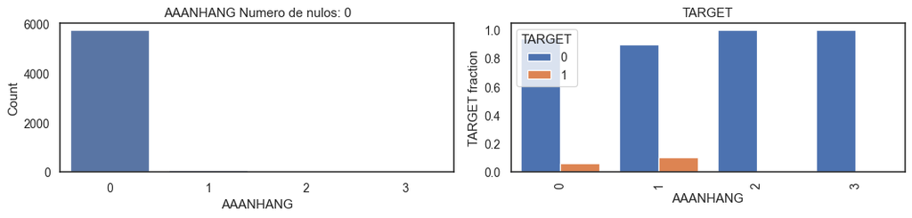

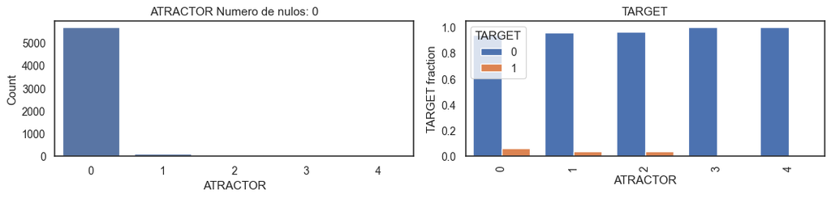

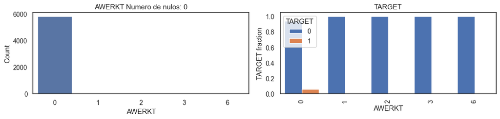

[11 more figures not shown]

```python
df_num_with_target =  df_num
df_num_with_target['TARGET'] = df['CARAVAN']

for i in list(df_num_with_target.columns):
    if (df_num_with_target[i].dtype==float) & (i!='TARGET'):
        plot_feature(df_num_with_target, col_name=i, isContinuous=True, target='TARGET')
    elif  i!='TARGET':
        plot_feature(df_num_with_target, col_name=i, isContinuous=False, target='TARGET')
```

## Conclusiones adicionales

Sospechamos que algunas variables categóricas y numéricas representan lo mismo.

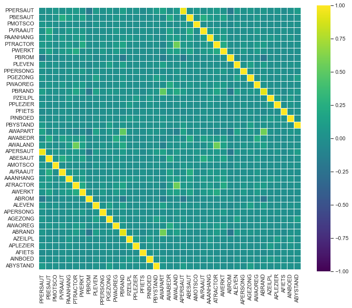

```
0
```

```python
df_aux = df.iloc[:,[*range(46,85)]]
get_corr_matrix(dataset = df_aux,
                metodo='spearman', size_figure=[12,10])
```

Cómo vemos en la matriz de correlacion, algunas tienen correlación muy fuerte de 1. Esto es porque realmente son variables que representan la misma información. Con la peculiaridad que algunas son numéricas y otras categóricas.